# Homework assignment 1

Data Science and Machine Learning 1 - CEU 2018

Peter Paziczki

2018 január 28

# 1. Model selection with a validation set

Loading the necessary packages:

```r
## loading necessary packages
library(data.table)
```

```r
library(ggplot2)
library(GGally)
library(lattice)
library(caret)
library(pander)
## loading the data
data <- fread("../data/king_county_house_prices/kc_house_data.csv")

## cleaning
data[, `:=`(floors = as.numeric(floors), zipcode = factor(zipcode))]
## creating log price
data[, log_price := log(price)]
## dropping unnecessary variables
data[, c("id", "date", "sqft_living15", "sqft_lot15", "price") := NULL]
```

### 1.1 Using `createDataPartition`, cut your data into three parts: 50% should be your training data, 25% each your validation and test sets (hint: cut data into two parts, then further cut one part into two).

```r
set.seed(1234)
training_ratio <- 0.5
train_indices_1 <- createDataPartition(y = data[["log_price"]],
                                     times = 1,
                                     p = training_ratio,
                                     list = FALSE)
data_train <- data[train_indices_1, ]
data_val_and_test <- data[-train_indices_1, ]
train_indices_2 <- createDataPartition(y = data_val_and_test[["log_price"]],
                                     times = 1,
                                     p = training_ratio,
                                     list = FALSE)
data_validation <- data_val_and_test[train_indices_2, ]
data_test <- data_val_and_test[-train_indices_2, ]
```

### 1.2 Train three models on the training data via caret, without cross validation (method = “none”):

- a linear model lm with only using sqft_living as a predictor (a simple benchmark)
- a linear model lm using all available features
- a regression tree (rpart) with cp = 0.0001 (the tune grid should be a dataframe with one column cp and one row with value 0.0001)

```r
train_control <- trainControl(method = "none")
tune_grid <- data.frame("cp" = 0.0001)

set.seed(1234)
simple_linear_fit <- train(log_price ~ sqft_living,
                   data = data_train,
                   method = "lm",
                   trControl = train_control)

linear_fit <- train(log_price ~ .,
                   data = data_train,
                   method = "lm",
                   trControl = train_control)

rpart_fit <- train(log_price ~ .,
                   data = data_train,
                   method = "rpart",
                   trControl = train_control,
                   tuneGrid = tune_grid)
```

### 1.3 Compare your models on the validation set and choose the one with the best performance (using RMSE). Use predict.train for prediction just like we used predict in class.

```r
RMSE <- function(x, true_x) sqrt(mean((x - true_x)^2))

simple_linear_rmse <- RMSE(predict.train(simple_linear_fit, data_validation),
                          data_validation[["log_price"]])
#simple_linear_rmse_2 <- RMSE(predict.train(simple_linear_fit, newdata = data_validation, type = 'raw'), data_validation$log_price)
simple_linear_rmse
```

```
## [1] 0.3797396
```

```r
linear_rmse <- RMSE(predict.train(linear_fit, data_validation),
                          data_validation[["log_price"]])
#linear_rmse_2 <- RMSE(predict.train(linear_fit, newdata = data_validation, type = 'raw'), data_validation$log_price)
linear_rmse
```

```
## [1] 0.190462
```

```r
rpart_rmse <- RMSE(predict.train(rpart_fit, data_validation),
                          data_validation[["log_price"]])
#rpart_rmse_2 <- RMSE(predict.train(rpart_fit, newdata = data_validation, type = 'raw'), data_validation$log_price)
rpart_rmse
```

```
## [1] 0.2192006
```

```r
performance_meause <- data.table("simple_linear_rmse" = simple_linear_rmse,
                     "linear_rmse" = linear_rmse,
                     "rpart_rmse" = rpart_rmse)
performance_meause
```

```
##    simple_linear_rmse linear_rmse rpart_rmse
## 1:          0.3797396    0.190462  0.2192006
```

The linear fit with only one predictor gave the highest RMSE (`0.3797396`), it is our benchmark. The linear modell and the regression tree gave better results using all the variables available, `0.190462` and `0.2192006` respectively. We can see that the linear model performed better compared to the regression tree.

### 1.4 Evaluate the final model on the test set. Why is it important to have this final set of observations set aside for evaluation? (Hint: think about what we used the validation set for.)

```r
final_performance_measure <- RMSE(predict.train(linear_fit, data_test),
                          data_test[["log_price"]])
#final_performance_measure_2 <- RMSE(predict.train(linear_fit, newdata = data_test, type = 'raw'), data_test$log_price)
final_performance_measure
```

```
## [1] 0.1885708
```

The three different data sets are used for different purposes. The training data set is used to fit the different models (two linear models and a regression tree in our case), while the validation data is used for model selection, the performance of different models are compared and the best is chosen. In our case the one that produced the lowest RMSE. Once the model is chosen, it is to be tested on a data set that was not used for training or model selection, this data set is independent of the others. (It is expected to have the same distribution as the training data set.) On this test data the generalization error of the final model is to be assessed.

### 1.5 Do you think it makes more sense to use this method rather than the one used in class? What can be advantages or disadvantages of one or the other?

When there is enough data, dividing it into parts is a good approach, because it is a good way of avoiding to overfit the model. In case of having scarce data unfortunately it is not an option to divide the data, because simply there wouldn’t be enough data left to work with. To overcome that problem K-fold crossvalidation can be used It uses a part of data to fit the model and another to test. This way we can work with smaller data sets. In our case we have more than 21.000 observation, so I believe we can go with the method requested in the previous exercise.

## 2. Predicting developer salaries

```r
data <- fread("../data/stackoverflow2017/survey_results_public_selected.csv")

data <- data[!is.na(Salary) & Salary > 0]
data <- data[complete.cases(data)]
data <- data[, Gender := ifelse(Gender == "Male", "Male",
                              ifelse(Gender == "Female", "Female", "Other"))]
large_countries <- data[, .N, by = "Country"][N > 60][["Country"]]
data <- data[, Country := ifelse(Country %in% large_countries, Country, "Other")]
```

### 2.1 Describe what the data cleansing steps mean.

In this exercise the task is to predict developer salaries using the Stackoverflow Annual Developer Survey 2017.

The data is not always provided in a way or form that is requested to be able to work with that or to yield the best possible results. Some data transformation and / or conversation is always needed before model estimation. Data might be converted to a different type of format (categorical or dummy variables), missing values might be dropped or replaced. Numeric values might need to be normalized, binned, scaled (to be able to compare them), etc. Often the natural logarithm of variables is taken to have less skewed distribution that are more amenable for modeling purposes.

In our case all the observation with missing salaries and zero salaries have been dropped. We have also dropped observations with NAs. In case of gender we have done some consolidation, there were missing values, transgenders, etc., no we have only three different genders female, male and others. We had observations from several countries, all the countries that were represented by less than 61 observation were categorized as “otehrs”.

### 2.2 Using graphs, find at least two interesting features that can contribute to understanding developer salaries.

#### 2.2.1 Mean salary by formal education

The below chart shows the mean salary by formal education. In the given data set developers with doctoral degree earn the most on average and those have a professional degree earn the least (not considering those who chose no to answer this survey question). Is is very interesting that, based on the data set, there are developers who only have primary / elementary school as formal education but earn more on average than those who have a master’s degree. This is something that is to be checked.

```r
## Mean salary by formal education
SalaryEdu <- data[, list(AvgSalary = mean(Salary)), by = FormalEducation][order(AvgSalary)]
pander(SalaryEdu)
```

| FormalEducation | AvgSalary |
| --- | --- |
| I prefer not to answer | 38285 |
| Professional degree | 39504 |
| Secondary school | 40448 |
| I never completed any formal education | 44431 |
| Some college/university study without earning a bachelor’s degree | 55940 |
| Bachelor’s degree | 56950 |
| Master’s degree | 58251 |
| Primary/elementary school | 62677 |
| Doctoral degree | 78528 |

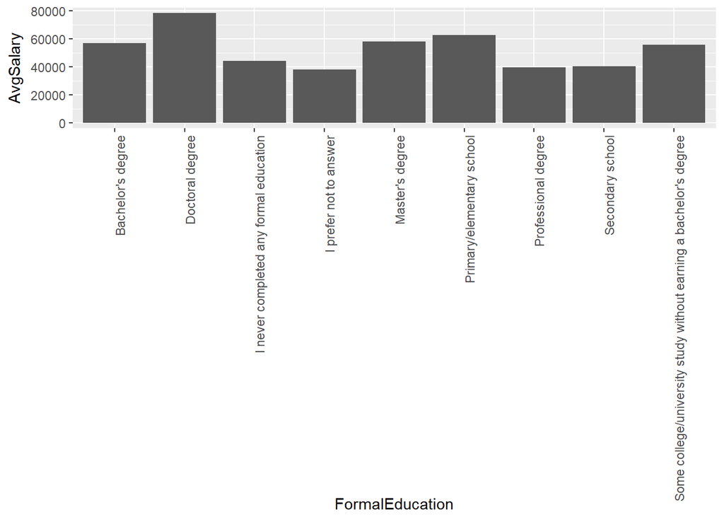

```r
ggplot(data = SalaryEdu, aes(x=FormalEducation, y=AvgSalary)) +
  geom_bar(stat = "identity") + theme(axis.text.x = element_text(angle = 90, hjust = 1))
```

We have seen interesting things above, it is definitely worth to see how many observation we have by education. We can see that only a few survey have been filled saying that the formal education was “Primary/elemntary school”, it might be a mistake. We can clearly see that, based on the survey, the majority of those who filled the survey have at least some academic background.

```r
data[,.N, by = FormalEducation][order(N)]
```

```
##                                                      FormalEducation    N
## 1:                                            I prefer not to answer   45
## 2:                                         Primary/elementary school   55
## 3:                            I never completed any formal education   60
## 4:                                               Professional degree  143
## 5:                                                   Doctoral degree  293
## 6:                                                  Secondary school  760
## 7: Some college/university study without earning a bachelor's degree 2049
## 8:                                                   Master's degree 3077
## 9:                                                 Bachelor's degree 6403
```

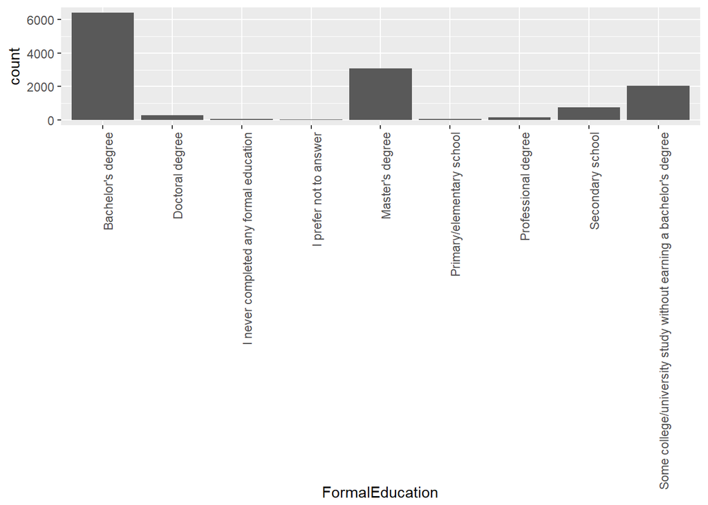

```r
ggplot(data, aes(FormalEducation)) + geom_bar() + theme(axis.text.x = element_text(angle = 90, hjust = 1))
```

```r
## Distribution of salaries by formal education
#ggplot(data, aes(Salary)) + geom_density()  + facet_wrap(~FormalEducation)
```

#### 2.2.2 Mean salary by country

The below charts show what is the average salary per country. Based on the given data it is the highest in Switzerland and in the United States, the lowest in Pakistan and India. Hungary is just slightly above the 1st quantile. Romania and Ukraine is behind Hungary, even Poland.

```r
## Mean salary by country
SalaryCountry <- data[, list(AvgSalary = mean(Salary)), by = (Country = as.factor(Country))][order(AvgSalary)]
SalaryCountry
```

```
##                Country AvgSalary
##  1:           Pakistan   8195.25
##  2:              India  10344.06
##  3:             Mexico  16511.20
##  4:             Turkey  18412.47
##  5: Russian Federation  18442.29
##  6:            Romania  19451.21
##  7:            Ukraine  19471.55
##  8:           Portugal  20527.55
##  9:             Brazil  20695.76
## 10:             Poland  20851.35
## 11:            Hungary  21049.10
## 12:     Czech Republic  21360.75
## 13:           Bulgaria  21544.21
## 14:              Other  25230.78
```

[output cut: 22 more lines]

```r
SalaryCountry[Country == "Hungary"]
```

```
##    Country AvgSalary
## 1: Hungary   21049.1
```

```r
summary(SalaryCountry$AvgSalary)
```

```
##    Min. 1st Qu.  Median    Mean 3rd Qu.    Max.
##    8195   20774   33564   39778   54764   96195
```

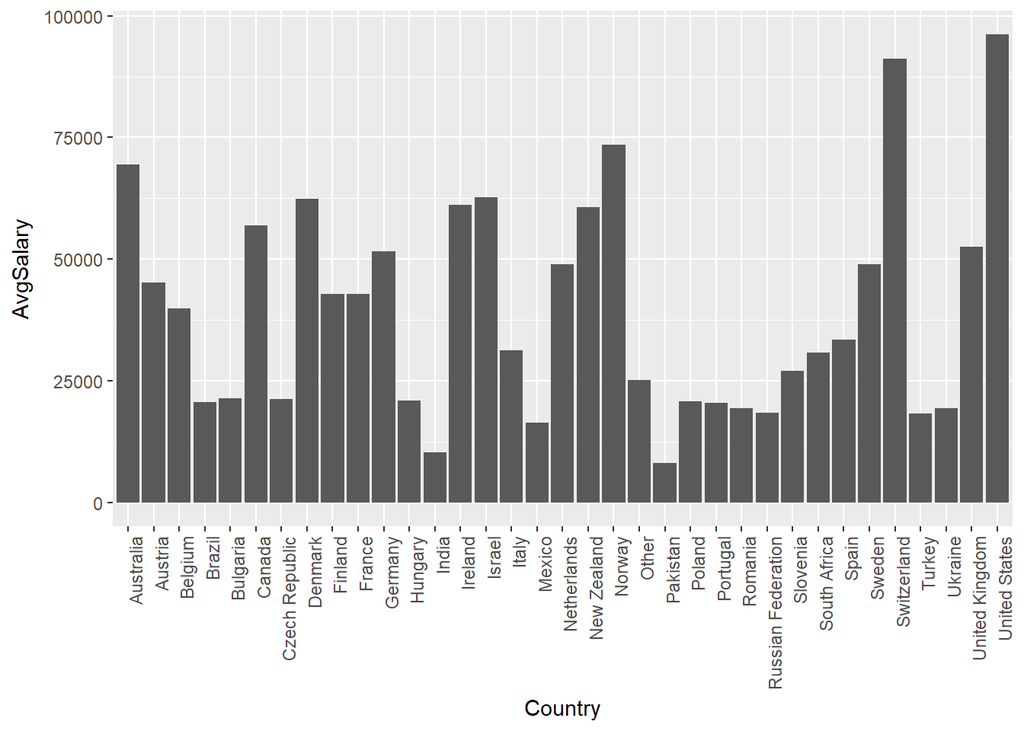

```r
ggplot(data = SalaryCountry, aes(x=Country, y=AvgSalary)) +
  geom_bar(stat = "identity") + theme(axis.text.x = element_text(angle = 90, hjust = 1))
```

#### 2.2.3 Number of developers by gender

The barchart shows that the majority of those who filled the survey were male.

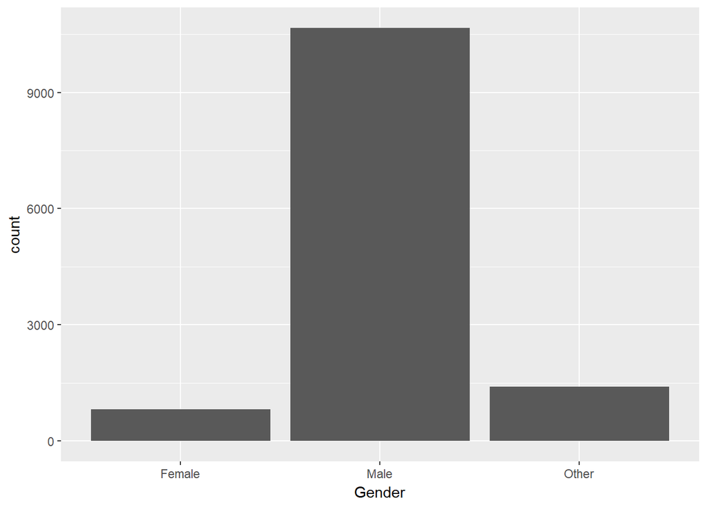

```r
## Number of people per Gender
ggplot(data, aes(Gender)) + geom_bar()
```

#### 2.2.4 Distribution of salaries across the data set

The below histogram shows the distribution of salaries in the data set, it is skewed to the right. It is to be investigated in more details. I am assuming that the salary means USD earned per year. If that assumption is correct, there are observation with practically earning a few dollars per year. Investigating it is not scope of this assignment, but it was important enough to highlight it.

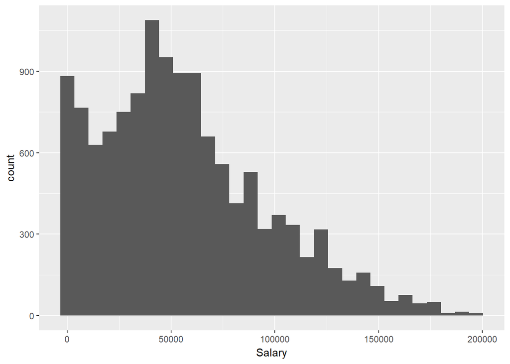

```r
## Distribution of salaries
ggplot(data, aes(Salary)) + geom_histogram()
```

```r
summary(data$Salary)
```

```
##      Min.   1st Qu.    Median      Mean   3rd Qu.      Max.
##      0.01  26515.15  50000.00  56324.70  80000.00 197000.00
```

#### 2.2.5 Distribution of salaries by gender

The below density chart shows the disribution of salaries by gender. We can say that the distribution between male and female is very similar, but it would take more to investigate whether there is a gender gap. It is also interesting that salary distribution of those whose gender is considered as “Other” have a different distribution, there are more observations in the 0 - 25.000 USD range than in case of female or male.

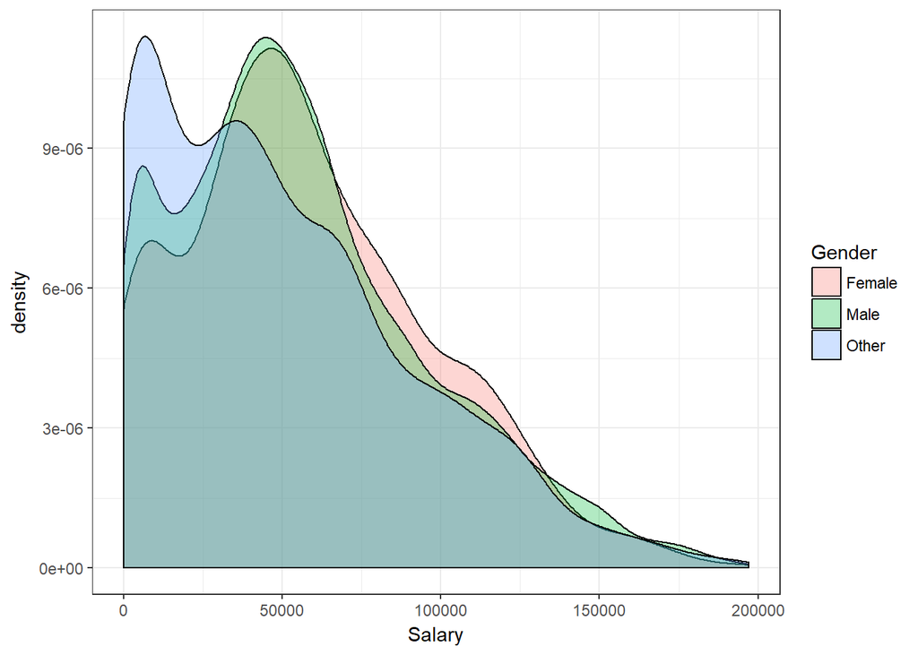

```r
## Distribution of salaries by gender
ggplot(data, aes(Salary, fill = Gender)) + geom_density(alpha = 0.3) + theme_bw()
```

The salary differences between genders is a concerning topic, let’s have a look at a boxplot of salaries by gender. Based on the data at hand females earn a bit more on average than male, but we know that a very few female have filled the survey.

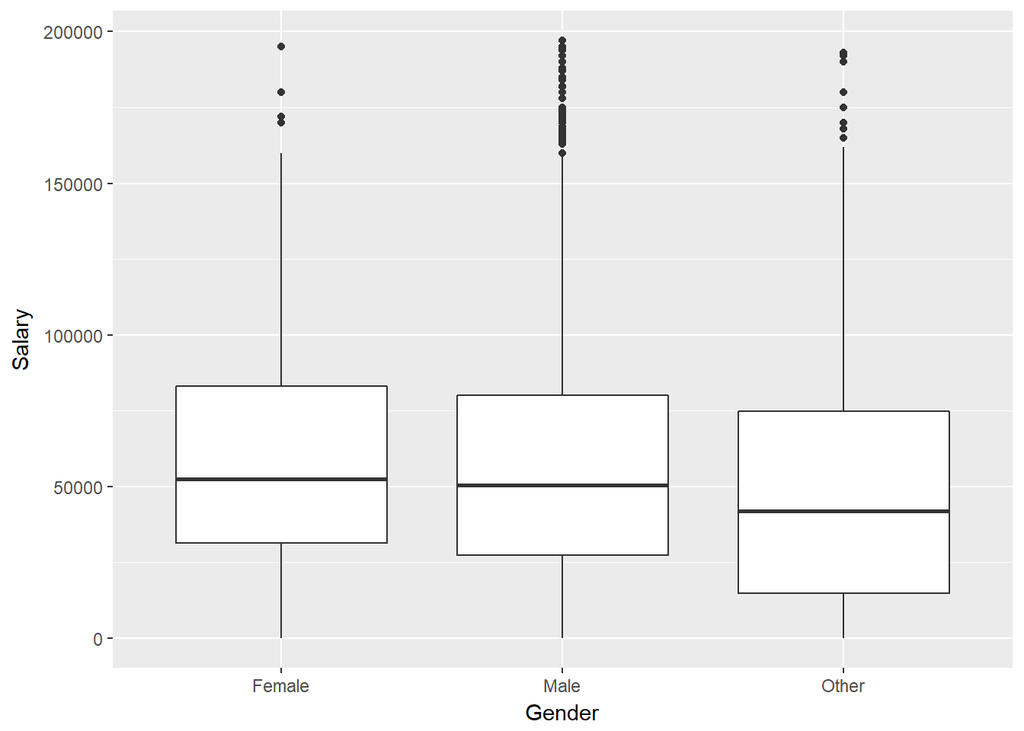

```r
## Boxplot of salaries by gender
ggplot(data, aes(Gender, Salary)) + geom_boxplot()
```

#### 2.2.6 Number of people per company size

The below barchart shows that the most represented company size is the companies with 20-99 employees. Not considering those who did not answer and couldn’t answer this question, the most underrepresented company size is the companies with 5,000 - 9,999 employees.

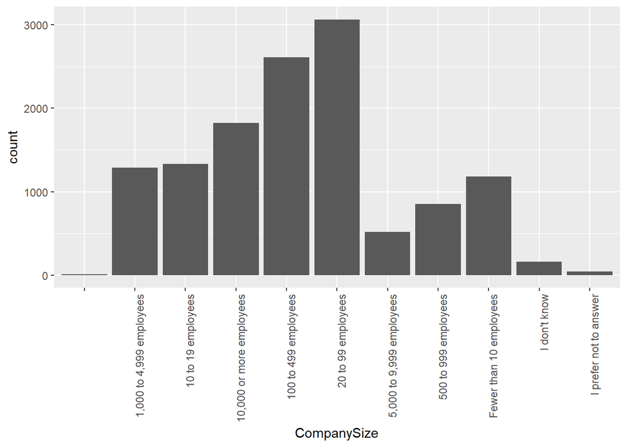

```r
## Number of people per company size
ggplot(data, aes(CompanySize)) + geom_bar() + theme(axis.text.x = element_text(angle = 90, hjust = 1))
```

```r
#ggplot(data, aes(x = Salary, FormalEducation)) + geom_point(alpha = 0.1)
#ggplot(data, aes(x = Salary, YearsProgram)) + geom_point(alpha = 0.1)
#ggplot(data, aes(x = Salary, CompanySize)) + geom_point(alpha = 0.1)
#ggplot(data, aes(x = Salary, FormalEducation)) + geom_point(alpha = 0.1) + facet_wrap(~CompanySize)
#ggplot(data, aes(log(Salary))) + geom_histogram()
#ggplot(data, aes(Salary, fill = FormalEducation)) + geom_density(alpha = 0.3) + theme_bw()
#ggplot(data, aes(Salary)) + geom_density()  + facet_wrap(~CompanySize)
## Number of people per country
#ggplot(data, aes(Country)) + geom_bar()
## Number of people per ProgramHobby
#ggplot(data, aes(ProgramHobby)) + geom_bar()
## Boxplot of salaries by FormalEducation
#ggplot(data, aes(FormalEducation, Salary)) + geom_boxplot()
```

### 2.3 Create a training and a test set assigning 70% to the training set and 30% as the test set.

```r
set.seed(1234)
data[, log_salary := log(Salary)]
training_ratio <- 0.7
train_indices <- createDataPartition(y = data[["Salary"]],
                                     times = 1,
                                     p = training_ratio,
                                     list = FALSE)
data_train <- data[train_indices, ]
data_test <- data[-train_indices, ]
```

### 2.4 Using caret train at least two predictive models to predict the logarithm of Salary (they can be of the same family but with different hyperparameters or they can be of different families like we used lm and rpart in the first exercise). Make sure NOT to include Salary as a predictor variable. Also, just before calling train, remember to use set.seed.

```r
train_control <- trainControl(method = "cv", number = 10)
tune_grid <- data.frame("cp" = c(0.01, 0.005,
                                 0.001, 0.0005,
                                 0.0001, 0.00005,
                                 0.00001, 0.000005))
N <- nrow(tune_grid)
```

I am choosing the method of regression trees with 8 different complexity parameters as hyperparameters and working with 10-fold cross-validation.

```r
set.seed(1234)

# linear_fit <- train(log_salary ~ . -Salary, data = data_train, method = "lm", trControl = train_control)

rpart_fit <- train(log_salary ~ . -Salary,
                   data = data_train,
                   method = "rpart",
                   trControl = train_control,
                   tuneGrid = tune_grid)
rpart_fit
```

```
## CART
##
## 9020 samples
##    8 predictor
##
## No pre-processing
## Resampling: Cross-Validated (10 fold)
## Summary of sample sizes: 8119, 8118, 8118, 8118, 8118, 8118, ...
## Resampling results across tuning parameters:
##
##   cp     RMSE       Rsquared   MAE
##   5e-06  1.0175034  0.4391235  0.5841289
##   1e-05  1.0171127  0.4394886  0.5838310
##   5e-05  1.0160150  0.4401763  0.5815440
##   1e-04  1.0127748  0.4430201  0.5789464
##   5e-04  0.9918077  0.4618013  0.5665474
##   1e-03  0.9898655  0.4626986  0.5733854
##   5e-03  1.0243028  0.4240387  0.6101183
##   1e-02  1.0631265  0.3795067  0.6406908
##
## RMSE was used to select the optimal model using the smallest value.
## The final value used for the model was cp = 0.001.
```

- choose the best model based on cross-validation estimation on the training set

The best performance (lowest RMSE = 0.9898655) has been achieved by the model using cp = 0.001.

- evaluate its performance on the test set

```r
rpart_rmse <- RMSE(predict.train(rpart_fit, data_test),
                          data_test[["log_salary"]])

rpart_rmse
```

```
## [1] 1.009924
```

Evaluating the model chosen above, the RMSE is 1.009924 on the test data set.

### 2.5 compare the true and predicted values of the test set on a graph. How do you evaluate the model fit based on this graph?

Please find scatterplots below showing the log_salary (true values) and log_salary_prediction (predicted values) pairs of the test set, with log_salary on the x axis and log_salary_prediction on the y axis. We can see horizontal “drawn by the points”, the reason for that is that regression tree has been chosen as prediction method. It clearly shows how the regression tree works, the same prediction can be assigned to different values. (If regression has been chosen, in that case different values would have been predicted for different observations.)

I have added a line with a slope of 1 to show where the prefect prediction would be. We can see that the model has a lot of errors.

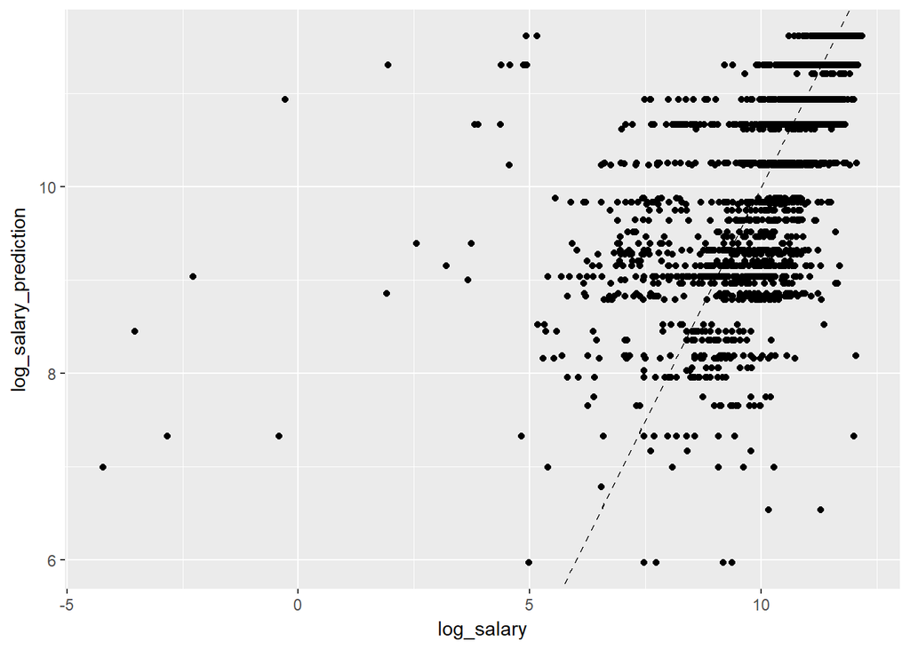

```r
#ggplot(rpart_fit) + scale_x_log10()

# Capturing the predictions
data_test[,log_salary_prediction := predict.train(rpart_fit, newdata = data_test)]
ggplot(data_test, aes(x = log_salary, log_salary_prediction)) + geom_point() +
  geom_abline(intercept = 0, slope = 1, linetype = "dashed")
```

(Sidenote: If only the salaries that are more than 1 were kept, the RMSE were a bit better.)

# 3. Leave-one-out cross validation

Leave-one-out cross validation (LOOCV) is a special case of k-fold cross validation where k equals the number of points in the sample.

## 3.1 Name a disadvantage of this method compared to using a moderate value (say, 10) for k?

The computational time and power needed to compute LOOCV is higher than doing a 5 or 10-fold cross-validation, so it is computationally intensive.

## 3.2 Why do you think it can still make sense to compute this measure? In what way can this measure be closer to the “real” performance of the model?

In case of having very scarce data it can be option as it works well on small data sets. A property of LOOCV is that it has low bias, but can have high variance, because all the observations are used for estimation except one which is used for test.

Loading the Titanic data set

```r
library(titanic)
library(data.table)

data_train <- data.table(titanic_train)
data_test <- data.table(titanic_test)
# recode Survived to factor - needed for binary prediction
data_train[, Survived := factor(ifelse(Survived == 1, "survived", "died"))]
```

## 3.3 You can implement LOOCV with caret by setting an option in trainControl: method = “loocv”. and use a simple logit model glm for prediction.

- In caret, you can use it via method = “glm”
- include classProbs = TRUE in trainControl to let train know that you are predicting a binary outcome
- Implement both an LOOCV and a 10-fold cross-validation estimation using only Fare and Sex as predictor features.

```r
train_control <- trainControl(method = "loocv",
                              #number = 10,
                              classProbs = TRUE) # means i am looking for binary probabilities
set.seed(1234)
glm_model_loocv <- train(Survived ~ Fare + Sex,
                   method = "glm",
                   data = data_train,
                   trControl = train_control)
glm_model_loocv
```

```
## Generalized Linear Model
##
## 891 samples
##   2 predictor
##   2 classes: 'died', 'survived'
##
## No pre-processing
## Resampling: Leave-One-Out Cross-Validation
## Summary of sample sizes: 890, 890, 890, 890, 890, 890, ...
## Resampling results:
##
##   Accuracy   Kappa
##   0.7822671  0
```

```r
train_control <- trainControl(method = "cv",
                              number = 10,
                              classProbs = TRUE) # means i am looking for binary probabilities
set.seed(1234)
glm_model_10fold <- train(Survived ~ Fare + Sex,
                   method = "glm",
                   data = data_train,
                   trControl = train_control)
glm_model_10fold
```

```
## Generalized Linear Model
##
## 891 samples
##   2 predictor
##   2 classes: 'died', 'survived'
##
## No pre-processing
## Resampling: Cross-Validated (10 fold)
## Summary of sample sizes: 802, 802, 802, 802, 802, 802, ...
## Resampling results:
##
##   Accuracy   Kappa
##   0.7834207  0.5375082
```

## 3.4 Compare the accuracy of the model estimated by the two resampling methods via summary(fitted_model$resample). Accuracy is the share of cases predicted correctly.

```r
summary(glm_model_loocv$resample)
```

```
##     Accuracy          Kappa       Resample
##  Min.   :0.0000   Min.   :0     Length:891
##  1st Qu.:1.0000   1st Qu.:0     Class :character
##  Median :1.0000   Median :0     Mode  :character
##  Mean   :0.7823   Mean   :0
##  3rd Qu.:1.0000   3rd Qu.:0
##  Max.   :1.0000   Max.   :0
##                   NA's   :697
```

```r
summary(glm_model_10fold$resample)
```

```
##     Accuracy          Kappa          Resample
##  Min.   :0.7191   Min.   :0.4017   Length:10
##  1st Qu.:0.7640   1st Qu.:0.5000   Class :character
##  Median :0.7809   Median :0.5224   Mode  :character
##  Mean   :0.7834   Mean   :0.5375
##  3rd Qu.:0.7949   3rd Qu.:0.5551
##  Max.   :0.8652   Max.   :0.7045
```

- How large are the means?

In case of the LOOCV the mean is 0.7823 and it is 0.7834 for the 10-fold cross-validation.

- How do other quantiles look like? Why are quantiles of the accuracy measures of LOOCV so extreme (either 0 or 1)?

Because there is only one observation I am tesing my model on each time, it is either 0 or 1, true are false. In case of 10-fold CV it is different, because I would test my model on more observation, some of them would be true and some of them would be false, and the average of those 0s and 1s can be greater or equal to 0 and less than or equal to 1.